# Predicting Excessive Enforcement Patterns in Police Behavior After Vehicles Stops in New York

# Bivariate EDA

## Categorical Association of Binary Response vs. Categorical Predictors

When dealing with a dataset of this size, traditional p-values from chi-squared tests become meaningless. To get around this, we use Cramer’s V to measure effect size (association).

Because of how the `table()` function works in R, we can also include integer predictors like `hour` and `age`: they do not take truly continuous values in this dataset, so treating each integer as its own category is valid.

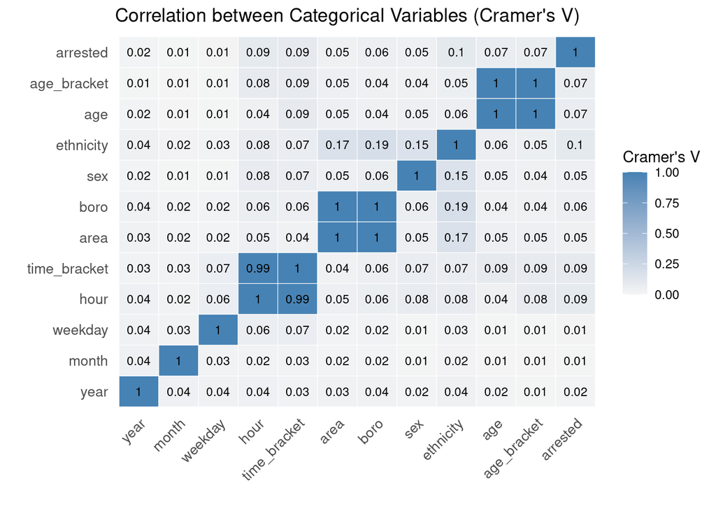

```r
# Excluding doy (redundant) and dow (we use weekday instead)
columns <- c(
  "year", "month", "weekday",
  "hour", "time_bracket",
  "area", "boro",
  "sex", "ethnicity", "age", "age_bracket",
  "arrested"
  )

plot_categorical_correlation(
  DF = vehstops,
  FEATURES = columns,
  TITLE = "Correlation between Categorical Variables (Cramer's V)"
)
```

What can we say?

- **Key finding**: The association matrix reveals that the only predictors showing a noticeable signal with `arrested` are, `ethnicity` ($0.1$), `hour`/`time_bracket` (both at $0.09$). Here, other demographic features such as `age`/`age_bracket` ($0.07$) and `sex` ($0.05$) have a more modest association. Spatial features like `boro` ($0.06$)/`area` ($0.05$) show very low, but still relevant signals. The matrix highlights a moderate association between these top predictors, specifically:
  - between `age`/`age_bracket` $\leftrightarrow$ `hour` / `time_bracket` ($\approx 0.08-0.09$)
  - between `sex` $\leftrightarrow$ `hour` / `time_bracket` ($\approx 0.07-0.08$)
  - between `ethnicity` $\leftrightarrow$ `hour` / `time_bracket` ($\approx 0.07-0.08$)
  - between `ethnicity` $\leftrightarrow$ `area`/`boro` ($0.17 - 0.19$)
  - between `ethnicity` $\leftrightarrow$ `sex` ($0.15$).
- **Interpretation**: Temporal and ethnic features carry the strongest individual baseline impacts when predicting an arrest, while standalone spatial attributes are less informative on their own for four-wheeled vehicles. The persistent $0.17$ to $0.19$ association between ethnicity and geography suggests that the demographic composition of stops remains non-uniformly distributed across different parts of the city.
- **Comment**: While the previous analysis shows a stronger connection to geographical signals (where `area` and `boro` scored $0.13$), here we probably encounter a more distributed arrest pattern. However, because no single predictor strongly correlates with `arrested`, models relying purely on main effects will likely underfit the data. Therefore, we must be careful when we consider the interactions.
- **Proposed Action**: Same as 2-wheels analysis, with the sole difference that here we focus a bit more on demographics then spatial features.

## Correlation of Binary Response vs. Numerical Predictors

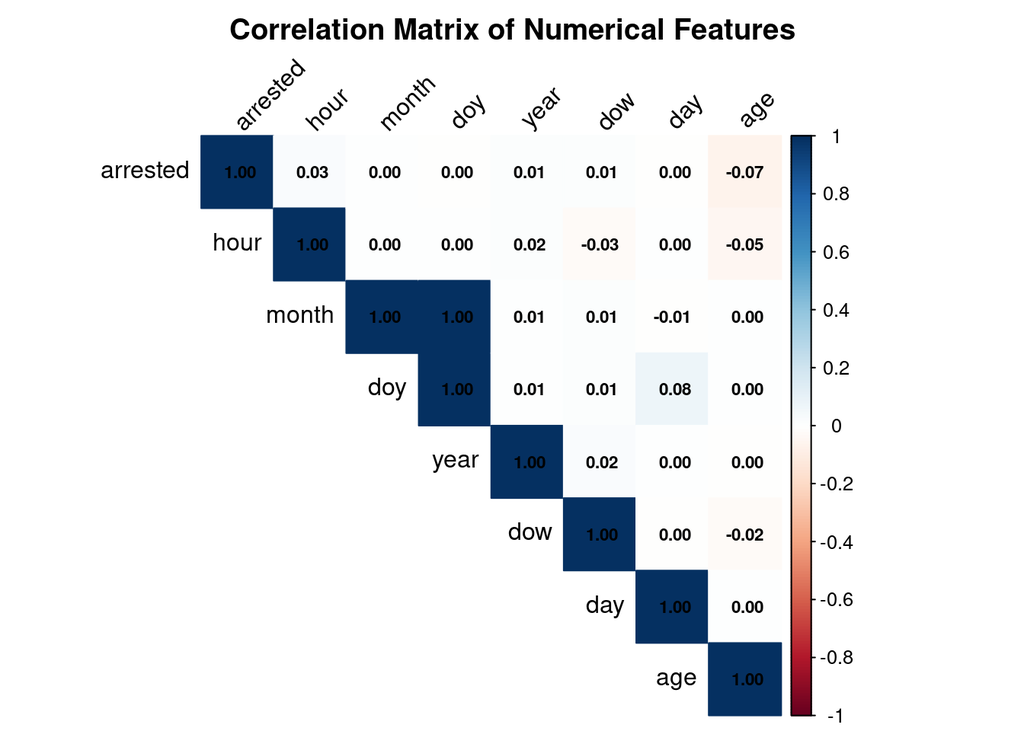

```r
# Ignoring Latitude and Longitude
numerical_cols <- c(
  "arrested",
  "year", "month", "day", "dow", "doy", "hour",
  "age"
  )

cor_matrix <- cor(vehstops[, numerical_cols], use = "complete.obs")

corrplot(cor_matrix, method = "color", type = "upper",
         order = "hclust", addCoef.col = "black", number.cex = 0.7,
         tl.col = "black", tl.srt = 45,
         title = "Correlation Matrix of Numerical Features",
         mar = c(0, 0, 2, 0))
```

What can we say?

- **Key finding**: The Pearson correlation matrix shows that our binary target `arrested` has a negligible linear relationship with all continuous numerical features. The strongest standalone linear relationship with the target appears in `age` ($-0.07$), which indicates a very slight negative trend, followed by `hour` ($0.03$). Calendar features like `month`, `doy` (day of year), `year`, `dow` (day of week), and `day` all show absolute correlation coefficients of $0.01$ or lower, indicating a complete absence of direct global linear relationships.
- **Interpretation**: The near-zero linear correlations across the board demonstrate that the probability of an arrest cannot be effectively modeled or predicted using standard linear relationships on raw numerical predictors. The slight negative value for `age` implies that older stopped drivers have a marginally lower likelihood of being arrested.
- **Comment**: Linear correlation metrics are not suited for capturing the dynamics of this dataset. This is probably due to the fact, both the features (like cyclical hours or seasonal months) and the target variable (`arrested`) act non-linearly.
- **Proposed Action**: We could explicitly map the continuous predictors using non-linear modeling frameworks, such as incorporating polynomial expansions or using Generalized Additive Models (GAMs) with smoothing splines for `age` and `hour`.

## Geospatial Features

### Area

```r
ratio_by_cat(
  vehstops, arrested, area,
  "Area", "Arrest Rate (%)", "Arrest Ratio by Area for Cars Stopped in NYC",
  style = "stack", legend_title = "Stop ended in arrest?",
  target_labels = c("No", "Yes"),
  subtitle = "Although the ratios are low, the amount of arrests, in proportion, are incredibly high",
  label_vjust = 0.5,
  bar_width = 0.6,
  text_size = 2.5,
  aspect_ratio = 0.9
)
```

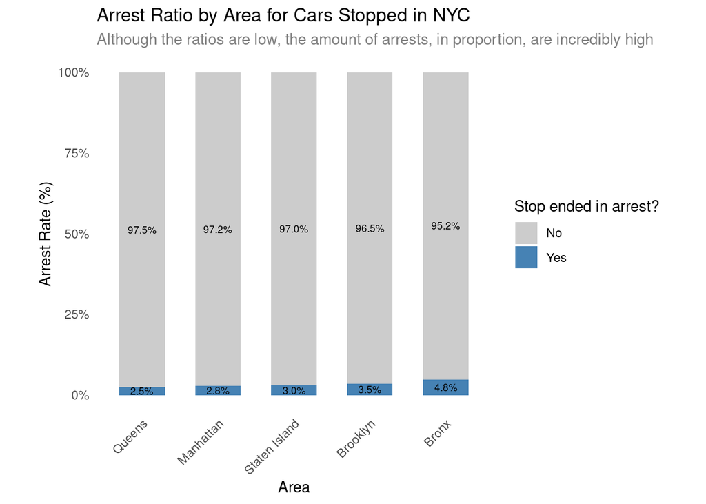

Let us look at the numbers too

```r
vehstops %>%
  group_by(area, arrested) %>%
  summarise(count = n(), .groups = "drop_last") %>%
  mutate(percentage = count / sum(count))
```

```
## # A tibble: 10 × 4
## # Groups:   area [5]
##    area          arrested  count percentage
##    <chr>            <int>  <int>      <dbl>
##  1 Bronx                0 361324     0.952
##  2 Bronx                1  18239     0.0481
##  3 Brooklyn             0 615375     0.965
##  4 Brooklyn             1  22099     0.0347
##  5 Manhattan            0 404153     0.972
##  6 Manhattan            1  11697     0.0281
##  7 Queens               0 533577     0.975
##  8 Queens               1  13569     0.0248
##  9 Staten Island        0 160583     0.970
## 10 Staten Island        1   4971     0.0300
```

What can we say?

- **Key finding**: The arrest rate ranges from a minimum of $2.5\%$ in Queens to a maximum of $4.8\%$ in the Bronx. This represents nearly a 2x increase in the conditional probability of an arrest depending purely on **where the stop occurs**. While the absolute majority of stops do not result in arrests across all territories, the Bronx consistently maintains the highest conversion rate, followed by Brooklyn at $3.5\%$, Staten Island at $3.0\%$, and Manhattan at $2.8\%$.
- **Interpretation**: The variance here is more stable, thanks to the size of the sample. As a consequence, even small fluctuations like the difference between $2.5\%$ in Queens and $4.8\%$ in the Bronx can be considered as a robust statistical signal. This confirms that geographic features are very important for our prediction.
- **Comment**: When compared against the previous analysis, car stops have a tighter distribution. However, the curious aspect we found concerns Bronx and Brooklyn areas. While they show a great difference in the total volume of stops, the amount of arrest (following a stop) is still comparable for those area. Furthermore, the amount of stops that **did not end up in an arrest**, in Brooklyn, is almost 2x with respect to the Bronx. In general we could say that the spatial distribution is smoother, but the Bronx still remains a problematic area. For this reason we wonder whether we could say that the Bronx is just a big “outlier” with respect to the remaining areas.
- **Proposed Action**: Same as 2-wheels analysis.

### Borough

```r
ratio_by_cat(
  vehstops, arrested, boro,
  "Borough", "Arrest Rate (%)", "Arrest Ratio by Borough for Cars Stopped in NYC",
  style = "stack", legend_title = "Stop ended in arrest?",
  target_labels = c("No", "Yes"),
  subtitle = "The arrest rate seems to be well distributed among the boroughs",
  label_vjust = 0.5,
  bar_width = 0.8,
  text_size = 2.5
)
```

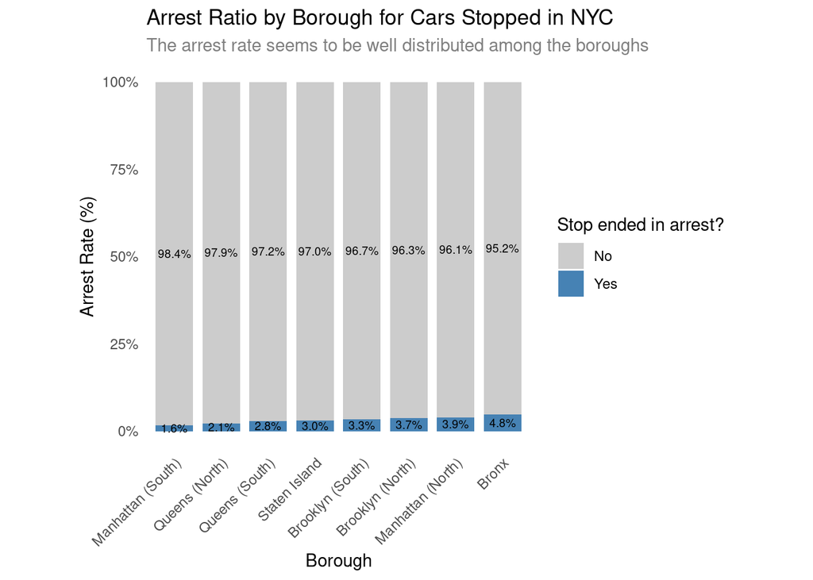

```r
vehstops %>%
  group_by(boro, arrested) %>%
  summarise(count = n(), .groups = "drop_last") %>%
  mutate(percentage = count / sum(count))
```

```
## # A tibble: 16 × 4
## # Groups:   boro [8]
##    boro              arrested  count percentage
##    <chr>                <int>  <int>      <dbl>
##  1 Bronx                    0 361324     0.952
##  2 Bronx                    1  18239     0.0481
##  3 Brooklyn (North)         0 232834     0.963
##  4 Brooklyn (North)         1   8995     0.0372
##  5 Brooklyn (South)         0 382541     0.967
##  6 Brooklyn (South)         1  13104     0.0331
##  7 Manhattan (North)        0 210935     0.961
##  8 Manhattan (North)        1   8580     0.0391
##  9 Manhattan (South)        0 193218     0.984
## 10 Manhattan (South)        1   3117     0.0159
## 11 Queens (North)           0 268567     0.979
## 12 Queens (North)           1   5862     0.0214
## 13 Queens (South)           0 265010     0.972
## 14 Queens (South)           1   7707     0.0283
## 15 Staten Island            0 160583     0.970
## 16 Staten Island            1   4971     0.0300
```

What can we say?

We will need to choose between one or the other.

### Latitude and Longitude for Stop Rate

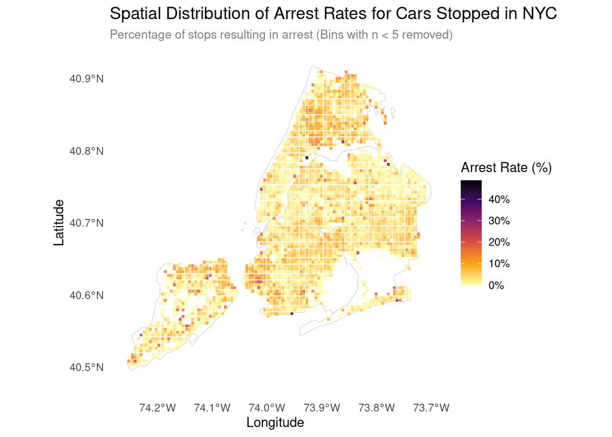

```r
nyc_map <- counties(state = "NY", cb = TRUE) %>%
  filter(NAME %in% c("Bronx", "Kings", "New York", "Queens", "Richmond"))

bins <- 100
lon_breaks <- seq(-74.26, -73.71, length.out = bins + 1)
lat_breaks <- seq(40.48, 40.92, length.out = bins + 1)

grid_sum_rate <- vehstops %>%
  filter(!is.na(longitude), !is.na(latitude), !is.na(arrested)) %>%
  mutate(
    xbin = cut(longitude, breaks = lon_breaks, include.lowest = TRUE, right = FALSE),
    ybin = cut(latitude, breaks = lat_breaks, include.lowest = TRUE, right = FALSE)
  ) %>%
  mutate(
    x = as.numeric(gsub(".*\\[(.*),.*", "\\1", xbin)) + (lon_breaks[2] - lon_breaks[1])/2,
    y = as.numeric(gsub(".*\\[(.*),.*", "\\1", ybin)) + (lat_breaks[2] - lat_breaks[1])/2
  ) %>%
  group_by(x, y) %>%
  summarise(
    total_stops = n(),
    arrest_rate = mean(arrested == 1),
    .groups = "drop"
  ) %>%
  filter(total_stops >= 5)

ggplot() +
  geom_sf(data = nyc_map, fill = "white", color = "grey80", linewidth = 0.2) +
  geom_tile(data = grid_sum_rate, aes(x, y, fill = arrest_rate), alpha = 0.8) +
  scale_fill_viridis_c(
    labels = scales::percent,
    name = "Arrest Rate (%)",
    option = "inferno",
    direction = -1
  ) +
  coord_sf(xlim = c(-74.26, -73.71), ylim = c(40.48, 40.92)) +
  theme_minimal() +
  theme(
    panel.grid = element_blank(),
    plot.title = element_text(size = 14),
    plot.subtitle = element_text(color = "grey50", size = 10)
  ) +
  labs(
    title = "Spatial Distribution of Arrest Rates for Cars Stopped in NYC",
    subtitle = "Percentage of stops resulting in arrest (Bins with n < 5 removed)",
    x = "Longitude",
    y = "Latitude"
  )
```

What can we say?

- **Key finding**: The plot shows a more decentralized distribution of arrest rates for cars, characterized mainly by a uniform baseline with light yellow to orange shades ($0\%$ to $15\%$). On the other hand, isolated hot spots are visible (dark purple and black pixels) across northern Manhattan, parts of the Bronx, eastern Queens, and central Staten Island. In some cases, these hotspots show arrest rates spiking above $40\%$, but this is due to the visualization threshold and scale.
- **Interpretation**: Same as 2-wheels analysis.
- **Comment**: Car enforcement presents a much more fragmented scene. The baseline risk is quite homogenous across the five boroughs, meaning that the spikes are highly localized exceptions rather than trends. It could be interesting to build a map for different boroughs and analyze how this visualization changes for different hours of the day, or periods of the year.

Note: This was made to be comparable with the EDA for 2-wheels case but the visualization itself would probably benefit from better binning and a higher threshold. In fact, it becomes a harder to demonstrate the effects this way.

## Time related features

### Year

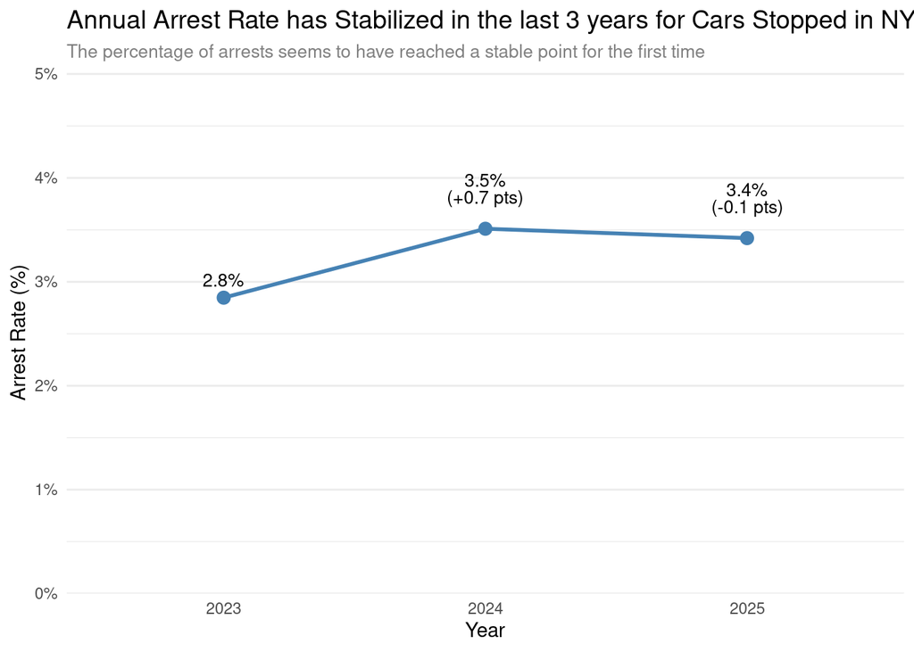

```r
arrest_trends <- vehstops %>%
  filter(!is.na(year), !is.na(arrested)) %>%
  group_by(year) %>%
  summarise(
    total_stops = n(),
    arrests = sum(arrested == 1),
    rate = arrests / total_stops,
    .groups = 'drop'
  ) %>%
  arrange(year) %>%
  mutate(
    prev_rate = lag(rate),
    delta = (rate - prev_rate) * 100,
    label_text = ifelse(
      is.na(prev_rate),
      scales::percent(rate, accuracy = 0.1),
      paste0(scales::percent(rate, accuracy = 0.1),
             "\n(", ifelse(delta > 0, "+", ""), round(delta, 1), " pts)")
    )
  )

ggplot(arrest_trends, aes(x = factor(year), y = rate, group = 1)) +
  geom_line(color = "steelblue", linewidth = 1) +
  geom_point(color = "steelblue", size = 3) +
  geom_text(aes(label = label_text), vjust = -0.8, size = 3.5, lineheight = 0.8) +
  scale_y_continuous(
    labels = scales::percent,
    limits = c(0, max(arrest_trends$rate) * 1.3),
    expand = expansion(mult = c(0, 0.1))
  ) +
  theme_minimal() +
  theme(
    panel.grid.major.x = element_blank(),
    plot.title = element_text(size = 14),
    plot.subtitle = element_text(size = 10, color = "grey50")
  ) +
  labs(
    title = "Annual Arrest Rate has Stabilized in the last 3 years for Cars Stopped in NYC",
    subtitle = "The percentage of arrests seems to have reached a stable point for the first time",
    x = "Year", y = "Arrest Rate (%)"
  )
```

What can we say?

- **Key finding**: The line chart displays the trajectory of the annual arrest rate for four-wheeled vehicles over a three-year period, revealing an initial rise followed by stabilization. The proportion of stops resulting in an arrest rose from $2.8\%$ in $2023$ to $3.5\%$ in $2024$ (a jump of $+0.7$ percentage points), followed by a marginal reduction to $3.4\%$ in $2025$.
- **Interpretation**: From a time-related perspective, this shows that the probability (of an arrest given a stop) shifted between $2023$ and $2024$ but has plateaued.
- **Proposed Action**: Same as 2-wheels analysis.

### Month

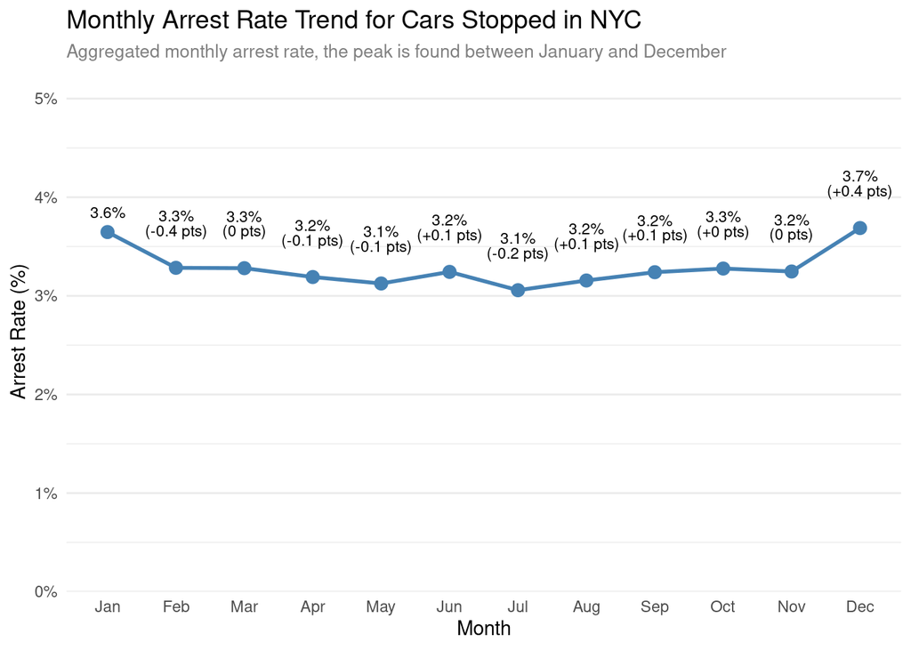

```r
monthly_arrest_data <- vehstops %>%
  filter(!is.na(month), !is.na(arrested)) %>%
  group_by(month) %>%
  summarise(
    total_stops = n(),
    arrests = sum(arrested == 1),
    rate = arrests / total_stops,
    .groups = "drop"
  ) %>%
  mutate(month = factor(month, levels = 1:12)) %>%
  arrange(month) %>%
  mutate(
    prev_rate = lag(rate),
    delta = (rate - prev_rate) * 100,
    label_text = ifelse(
      is.na(prev_rate),
      scales::percent(rate, accuracy = 0.1),
      paste0(scales::percent(rate, accuracy = 0.1),
             "\n(", ifelse(delta > 0, "+", ""), round(delta, 1), " pts)")
    )
  )

monthly_arrest_data %>%
  ggplot(aes(x = month, y = rate, group = 1)) +
  geom_line(color = "steelblue", linewidth = 1) +
  geom_point(color = "steelblue", size = 3) +
  geom_text(aes(label = label_text), vjust = -1.2, size = 3, lineheight = 0.8) +
  scale_x_discrete(labels = month.abb) +
  scale_y_continuous(
    labels = scales::percent,
    limits = c(0, max(monthly_arrest_data$rate) * 1.3),
    expand = expansion(mult = c(0, 0.1))
  ) +
  theme_minimal() +
  theme(
    panel.grid.major.x = element_blank(),
    plot.title = element_text(size = 14),
    plot.subtitle = element_text(color = "grey50", size = 10)
  ) +
  labs(
    title = "Monthly Arrest Rate Trend for Cars Stopped in NYC",
    subtitle = "Aggregated monthly arrest rate, the peak is found between January and December",
    x = "Month",
    y = "Arrest Rate (%)"
  )
```

What can we say?

- **Key finding**: The monthly arrest rate across the years, shows a highly stable pattern with some slight peaks concentrated at the absolute ends of the calendar year. The arrest rate starts at $3.6\%$ in January, then drops and plateaus between $3.1\%$ and $3.3\%$ from February through November. Finally, it shows a small surge to its annual peak of $3.7\%$ in December ($+0.4$ percentage points).
- **Interpretation**: From a temporal perspective, it seems that the probability of an arrest given a stop is essentially invariant.

#### Faceted

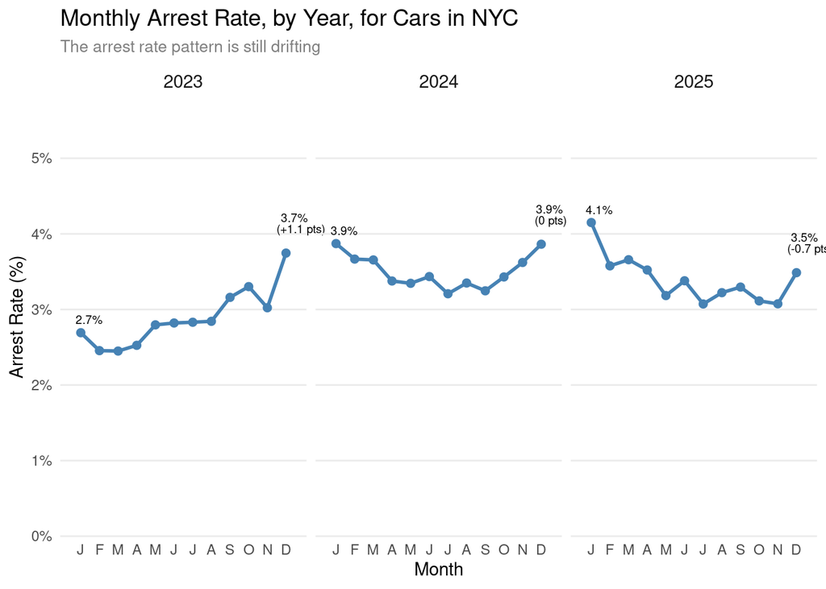

```r
plot_data <- vehstops %>%
  filter(!is.na(year), !is.na(month), !is.na(arrested)) %>%
  group_by(year, month) %>%
  summarise(
    arrest_rate = mean(arrested == 1),
    .groups = "drop"
  ) %>%
  mutate(month = factor(month, levels = 1:12)) %>%
  group_by(year) %>%
  mutate(
    rate_jan = arrest_rate[month == 1],
    rate_max = max(arrest_rate),
    is_max = arrest_rate == rate_max,

    diff_jan = (arrest_rate - rate_jan) * 100,
    diff_dec = (arrest_rate - rate_max) * 100,

    label_text = case_when(
      month == 1 ~ scales::percent(arrest_rate, accuracy = 0.1),
      is_max ~ paste0(scales::percent(arrest_rate, accuracy = 0.1), "\n(", ifelse(diff_jan > 0, "+", ""), round(diff_jan, 1), " pts)"),
      month == 12 ~ paste0(scales::percent(arrest_rate, accuracy = 0.1), "\n(", round(diff_dec, 1), " pts)"),
      TRUE ~ ""
    )
  )


plot_data %>%
  ggplot(aes(x = month, y = arrest_rate, group = 1)) +
  geom_line(color = "steelblue", linewidth = 1) +
  geom_point(color = "steelblue", size = 2) +
  geom_text(aes(label = label_text), vjust = -1, hjust = 0.2, size = 2.5, lineheight = 0.8) +
  facet_wrap(~year, nrow = 1) +
  scale_x_discrete(
    labels = c("J", "F", "M", "A", "M", "J", "J", "A", "S", "O", "N", "D"),
    expand = expansion(mult = c(0.1, 0.1))
  ) +
  scale_y_continuous(labels = scales::percent, limits = c(0, NA), expand = expansion(mult = c(0, 0.4))) +
  coord_cartesian(clip = "off") +
  theme_minimal() +
  theme(
    panel.grid.major.x = element_blank(),
    panel.grid.minor = element_blank(),
    plot.title = element_text(size = 14),
    plot.subtitle = element_text(color = "grey50", size = 10),
    strip.text = element_text(size = 11)
  ) +
  labs(
    title = "Monthly Arrest Rate, by Year, for Cars in NYC",
    subtitle = "The arrest rate pattern is still drifting",
    x = "Month",
    y = "Arrest Rate (%)"
  )
```

What can we say?

### Day, Dow and Weekday

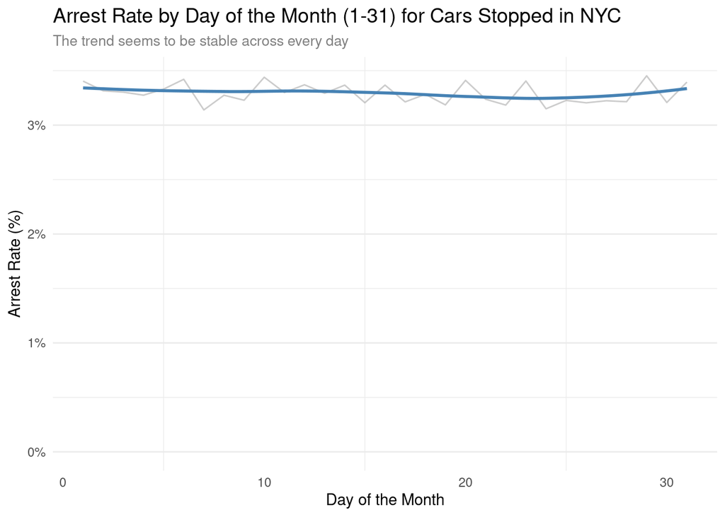

```r
daily_arrest_rate <- vehstops %>%
  filter(!is.na(day), !is.na(arrested)) %>%
  group_by(day) %>%
  summarise(
    total_stops = n(),
    arrests = sum(arrested == 1),
    rate = arrests / total_stops,
    .groups = "drop"
  )

daily_arrest_rate %>%
  ggplot(aes(x = day, y = rate)) +
  geom_line(color = "grey60", alpha = 0.5) +
  geom_smooth(method = "loess", color = "steelblue", se = FALSE) +
  scale_y_continuous(labels = scales::percent, limits = c(0, NA)) +
  theme_minimal() +
  theme(
    panel.grid.major.x = element_blank(),
    plot.title = element_text(size = 14),
    plot.subtitle = element_text(color = "grey50", size = 10)
  ) +
  labs(
    title = "Arrest Rate by Day of the Month (1-31) for Cars Stopped in NYC",
    subtitle = "The trend seems to be stable across every day",
    x = "Day of the Month",
    y = "Arrest Rate (%)"
  )
```

What can we say?

- **Key finding**: Arrest rates are broadly flat across days 1 through 31, showing no meaningful trend.
- **Interpretation**: The flat pattern across days 1-28 indicates that the day-of-month variable carries no genuine enforcement signal.
- **Proposed Action**: Exclude `day` from our models.

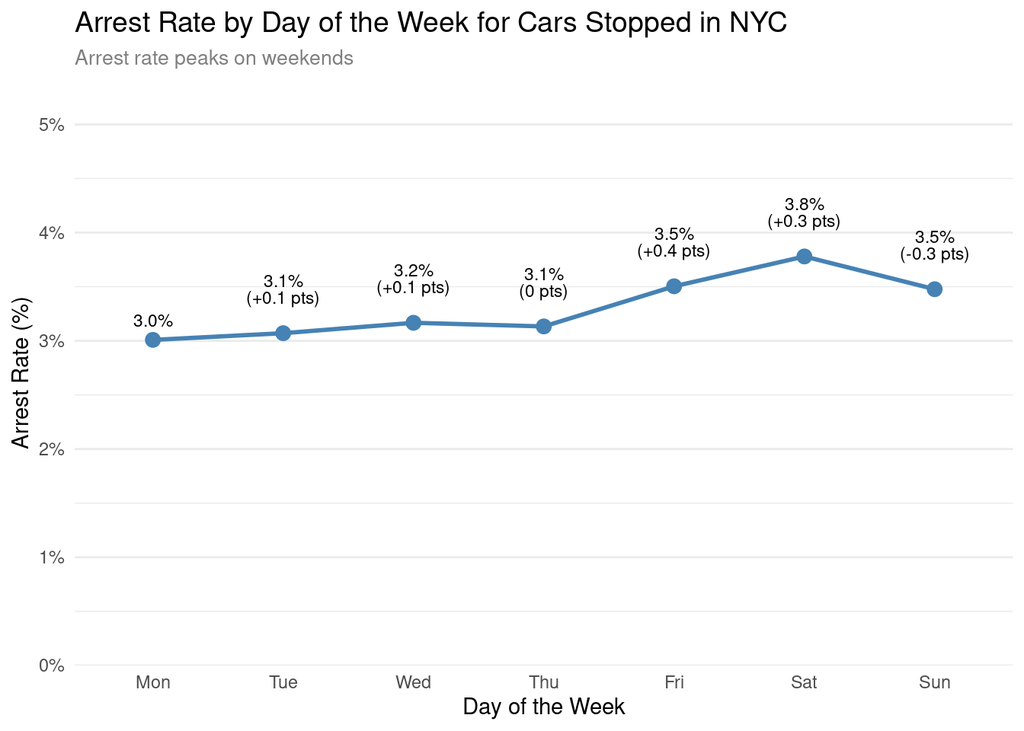

```r
daily_arrest_rate <- vehstops %>%
  filter(!is.na(dow), !is.na(arrested)) %>%
  group_by(dow) %>%
  summarise(
    total_stops = n(),
    arrests = sum(arrested == 1),
    rate = arrests / total_stops,
    .groups = "drop"
  ) %>%
  mutate(
    dow_label = factor(dow, levels = 1:7,
                       labels = c("Mon", "Tue", "Wed", "Thu", "Fri", "Sat", "Sun")),
    prev_rate = lag(rate),
    delta = (rate - prev_rate) * 100,
    label_text = ifelse(
      is.na(prev_rate),
      scales::percent(rate, accuracy = 0.1),
      paste0(scales::percent(rate, accuracy = 0.1),
             "\n(", ifelse(delta > 0, "+", ""), round(delta, 1), " pts)")
    )
  )

daily_arrest_rate %>%
  ggplot(aes(x = dow_label, y = rate, group = 1)) +
  geom_line(color = "steelblue", linewidth = 1) +
  geom_point(color = "steelblue", size = 3) +
  geom_text(aes(label = label_text), vjust = -1.0, size = 3, lineheight = 0.8) +
  scale_y_continuous(
    labels = scales::percent,
    limits = c(0, max(daily_arrest_rate$rate) * 1.3),
    expand = expansion(mult = c(0, 0.1))
  ) +
  theme_minimal() +
  theme(
    panel.grid.major.x = element_blank(),
    plot.title = element_text(size = 14),
    plot.subtitle = element_text(color = "grey50", size = 10)
  ) +
  labs(
    title = "Arrest Rate by Day of the Week for Cars Stopped in NYC",
    subtitle = "Arrest rate peaks on weekends",
    x = "Day of the Week",
    y = "Arrest Rate (%)"
  )
```

What can we say?

### Hour and Time Bracket

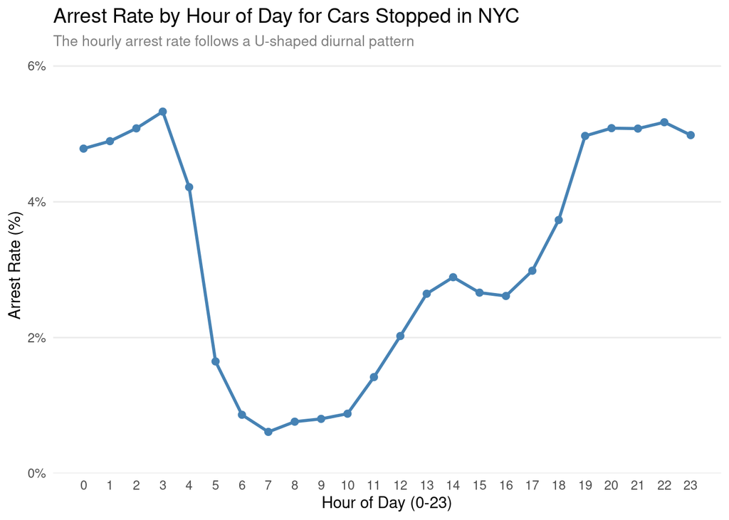

```r
hourly_arrest_rate <- vehstops %>%
  filter(!is.na(hour), !is.na(arrested)) %>%
  group_by(hour) %>%
  summarise(
    total_stops = n(),
    arrests = sum(arrested == 1),
    rate = arrests / total_stops,
    .groups = "drop"
  )

hourly_arrest_rate %>%
  ggplot(aes(x = hour, y = rate)) +
  geom_line(color = "steelblue", linewidth = 1) +
  geom_point(color = "steelblue", size = 2) +
  scale_x_continuous(breaks = 0:23) +
  scale_y_continuous(labels = scales::percent, limits = c(0, NA),
                     expand = expansion(mult = c(0, 0.15))) +
  theme_minimal() +
  theme(
    panel.grid.major.x = element_blank(),
    panel.grid.minor = element_blank(),
    plot.title = element_text(size = 14),
    plot.subtitle = element_text(color = "grey50", size = 10)
  ) +
  labs(
    title = "Arrest Rate by Hour of Day for Cars Stopped in NYC",
    subtitle = "The hourly arrest rate follows a U-shaped diurnal pattern",
    x = "Hour of Day (0-23)",
    y = "Arrest Rate (%)"
  )
```

What can we say?

- **Key finding**: The line plot underlines a distinct time-dependent pattern in the arrest rate resulting from stops across a $24$-hour cycle. We observe a global minimum at $7:00$ ($07:00$ AM) where the arrest rate drops to around $0.6\%$, followed by a steady climb to a minor afternoon peak around $14:00$ ($02:00$ PM) near $2.9\%$. The absolute maximum occurs during the late-night and early-morning hours, specifically peaking at $3:00$ ($03:00$ AM) with an arrest rate reaching approximately $5.3\%$.
- **Interpretation**: This strong fluctuation suggests that, depending on the hour of the day, a stop is more likely to turn into an arrest. However, we are not able to tell whether this is the result of a change in police behavior or the driver’s.
- **Comment**: When comparing this curve to the 2-wheeled analysis, we notice a remarkable similarity in their shape, even if here we start at a lower absolute maximum ($5.3\%$ versus nearly $11\%$). The remaining observations are the same of the 2-wheels analysis.
- **Proposed Action**: We may opt for the engineered `time_bracket` predictor. Also, we can test whether a continuous spline function using `hour` inside a Generalized Additive Model performs better than bucketing.

Let us look at our grouping now

```r
ratio_by_cat(
  vehstops, arrested, time_bracket,
  "Time bracket", "Arrest Rate (%)", "Arrest ratio by Custom Time Bracket for Cars Stopped in NYC",
  style = "stack", legend_title = "Stop ended in arrest?", target_labels = c("No", "Yes"),
  subtitle = "The night brackets show a slightly higher arrest rates among all"
)
```

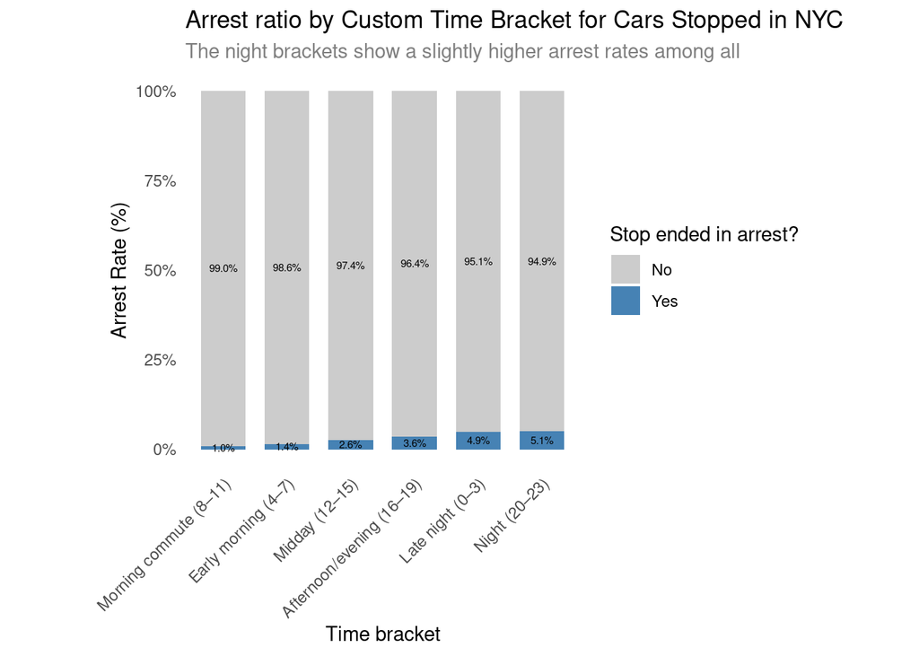

```r
vehstops %>%
  group_by(time_bracket, arrested) %>%
  summarise(count = n(), .groups = "drop_last") %>%
  mutate(percentage = count / sum(count))
```

```
## # A tibble: 12 × 4
## # Groups:   time_bracket [6]
##    time_bracket              arrested  count percentage
##    <chr>                        <int>  <int>      <dbl>
##  1 Afternoon/evening (16–19)        0 524542    0.964
##  2 Afternoon/evening (16–19)        1  19449    0.0358
##  3 Early morning (4–7)              0 136217    0.986
##  4 Early morning (4–7)              1   1946    0.0141
##  5 Late night (0–3)                 0 277611    0.951
##  6 Late night (0–3)                 1  14421    0.0494
##  7 Midday (12–15)                   0 308193    0.974
##  8 Midday (12–15)                   1   8091    0.0256
##  9 Morning commute (8–11)           0 402540    0.990
## 10 Morning commute (8–11)           1   3905    0.00961
## 11 Night (20–23)                    0 425909    0.949
## 12 Night (20–23)                    1  22763    0.0507
```

What can we say?

## Driver related features

### Reported Age

```r
ratio_by_cat(
  vehstops, arrested, age_bracket,
  "Reported Age Bracket", "Arrest Rate (%)", "Arrest Ratio by Reported Age Bracket for Cars Stopped in NYC",
  style = "stack", legend_title = "Stop ended in arrest?", target_labels = c("No", "Yes"),
  subtitle = "The 18-34 age bracket shows the highest arrest rates",
  label_vjust = 0.5,
)
```

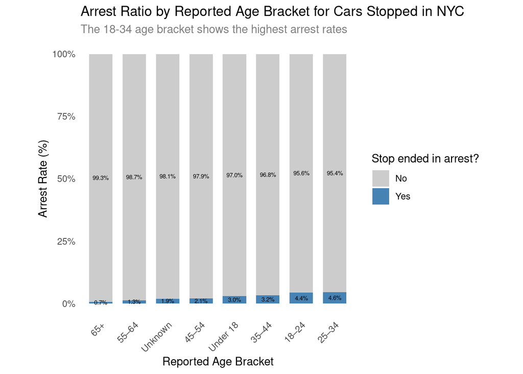

```r
vehstops %>%
  group_by(age_bracket, arrested) %>%
  summarise(count = n(), .groups = "drop_last") %>%
  mutate(percentage = count / sum(count))
```

```
## # A tibble: 16 × 4
## # Groups:   age_bracket [8]
##    age_bracket arrested  count percentage
##    <chr>          <int>  <int>      <dbl>
##  1 18–24              0 313593    0.956
##  2 18–24              1  14380    0.0438
##  3 25–34              0 602413    0.954
##  4 25–34              1  28821    0.0457
##  5 35–44              0 457198    0.968
##  6 35–44              1  15355    0.0325
##  7 45–54              0 297165    0.979
##  8 45–54              1   6334    0.0209
##  9 55–64              0 200457    0.987
## 10 55–64              1   2596    0.0128
## 11 65+                0  78467    0.993
## 12 65+                1    520    0.00658
## 13 Under 18           0   9020    0.970
## 14 Under 18           1    278    0.0299
## 15 Unknown            0 116699    0.981
## 16 Unknown            1   2291    0.0193
```

What can we say?

- **Key finding**: This plot shows a clear demographic trend where the arrest rate generally increases as the reported age bracket gets younger, reaching its absolute peak in the $25–34$ label. The lowest arrest rate is found within the $65+$ demographic at $0.66\%$ (specifically $520$ arrests). The highest ratio belongs to the $25–34$ bracket, where the arrest rate reaches $4.57\%$ aka $28,821$ arrests. The $18–24$ group closely follows with a $4.38\%$ arrest rate ($14,380$ arrests). Unlike the 2-wheeled analysis, the under $18$ bracket sits at a lower rate of $2.99\%$ ($278$ arrests), and the Unknown category shows a $1.93\%$ arrest rate ($2291$ arrests).
- **Interpretation**: The data shows a pronounced effect where young adults (ages $18$ to $34$) face the highest probability of arrest upon being stopped in a car. This differs from the previous analysis where minors (Under $18$) showed the highest arrest rate.
- **Comment**: For 2-wheeled vehicles, the younger brackets (especially minors) were heavily penalized, whereas for cars, the risk concentrates heavily on the $25–34$ bracket.
- **Proposed Action**: Same as 2-wheels analysis.